# Statistic Calculate Method

#### HW3 201811526 이은주

```r
library(tidyverse)
library(nycflights13)
```

### p.50 - p.51

1. Come up with another approach that will give you the same output as not_cancelled %>% count(dest) and not_cancelled %>% count(tailnum, wt = distance) (without using count()).

```r
not_cancelled = flights %>% filter(!is.na(dep_delay), !is.na(arr_delay))
```

1-1) not_cancelled %>% count(dest)

```r
not_cancelled %>%
  group_by(dest) %>%
  summarise(n())
```

```
## # A tibble: 104 x 2
##    dest  `n()`
##    <chr> <int>
##  1 ABQ     254
##  2 ACK     264
##  3 ALB     418
##  4 ANC       8
##  5 ATL   16837
##  6 AUS    2411
##  7 AVL     261
##  8 BDL     412
##  9 BGR     358
## 10 BHM     269
## # ... with 94 more rows
```

- group_by를 이용하여 dest별 몇 개의 데이터가 있는지 계산한다.

1-2) not_cancelled %>% count(tailnum, wt=distance)

```r
not_cancelled %>%
  group_by(tailnum) %>%
  summarise(sum(distance))
```

```
## # A tibble: 4,037 x 2
##    tailnum `sum(distance)`
##    <chr>             <dbl>
##  1 D942DN             3418
##  2 N0EGMQ           239143
##  3 N10156           109664
##  4 N102UW            25722
##  5 N103US            24619
##  6 N104UW            24616
##  7 N10575           139903
##  8 N105UW            23618
##  9 N107US            21677
## 10 N108UW            32070
## # ... with 4,027 more rows
```

- distance 가중치를 주어 count하므로 tailnum별 distance를 모두 더한다.

2) Look at the number of canceled flights per day. Is there a pattern? Is the proportion of canceled flights related to the average delay?

```r
(cancel = flights %>% group_by(year,month, day) %>%
  summarise(cancel_n = sum(is.na(dep_delay)|is.na(arr_delay)),
            cancel_prop = mean(is.na(dep_delay)|is.na(arr_delay)),
            average_delay = sum(dep_delay>0|arr_delay>0, na.rm=TRUE)))
```

```
## # A tibble: 365 x 6
## # Groups:   year, month [12]
##     year month   day cancel_n cancel_prop average_delay
##    <int> <int> <int>    <int>       <dbl>         <int>
##  1  2013     1     1       11     0.0131            539
##  2  2013     1     2       15     0.0159            635
##  3  2013     1     3       14     0.0153            575
##  4  2013     1     4        7     0.00765           450
##  5  2013     1     5        3     0.00417           341
##  6  2013     1     6        3     0.00361           480
##  7  2013     1     7        3     0.00322           378
##  8  2013     1     8        7     0.00779           370
##  9  2013     1     9        9     0.00998           349
## 10  2013     1    10        3     0.00322           286
## # ... with 355 more rows
```

- cancel_n = day별 취소 수
- cancel_prop = day별 취소 확률
- average_delay = day별 평균 delay 횟수

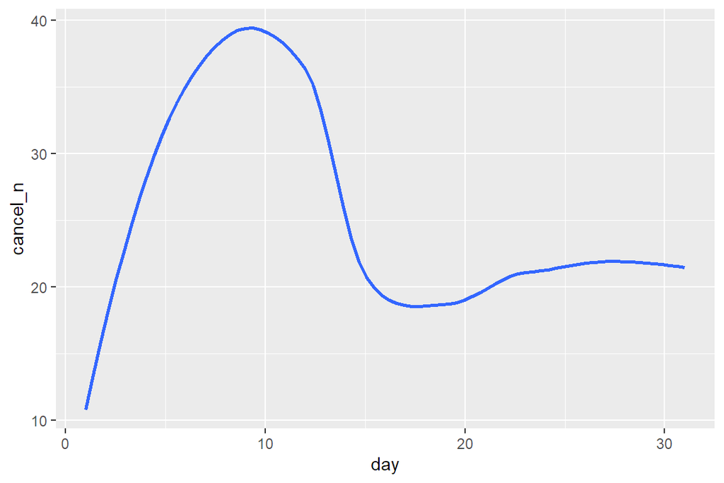

```r
cancel %>% ggplot(aes(x=day,y=cancel_n)) +
  geom_smooth(se=FALSE)
```

- Day별 취소 수 - 대체로 8~12일에 취소 수가 가장 많다.

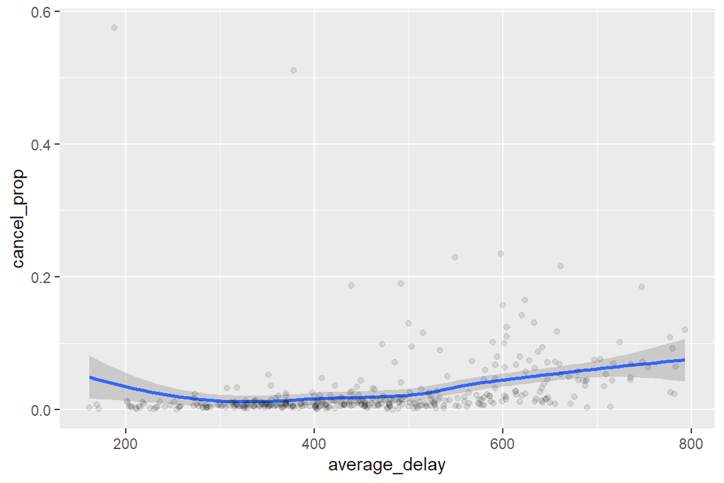

```r
cancel %>% ggplot(aes(x=average_delay, y=cancel_prop)) +
  geom_smooth() + geom_point(alpha=0.1)
```

- 평균 delday수와 cancel 확률 관계 - delay 수가 많을수록 cancel될 확률이 높다.
3. Which carrier has the worst delays? Challenge: can you disentangle the effects of bad airports vs. bad carriers? Why/why not? (Hint: think about flights %>% group_by(carrier, dest) %>% summarise(n()))

```r
(car =flights %>% group_by(carrier) %>%
  summarise(delay_n=sum(arr_delay>0, na.rm=TRUE),
            delay_prop=mean(arr_delay>0, na.rm=TRUE)) %>%
   arrange(desc(delay_n)))
```

```
## # A tibble: 16 x 3
##    carrier delay_n delay_prop
##    <chr>     <int>      <dbl>
##  1 EV        24484      0.479
##  2 B6        23609      0.437
##  3 UA        22222      0.385
##  4 DL        16413      0.344
##  5 MQ        11693      0.467
##  6 AA        10706      0.335
##  7 US         7349      0.371
##  8 9E         6637      0.384
##  9 WN         5304      0.440
## 10 FL         1895      0.597
## 11 VX         1746      0.341
## 12 F9          392      0.576
## 13 YV          258      0.474
## 14 AS          189      0.267
## 15 HA           97      0.284
## 16 OO           10      0.345
```

- EV carrier가 가장 delay 횟수가 많았다.

```r
(des = flights %>%
  group_by(carrier, dest, origin) %>%
  summarise(n = n(),
        dest_delay_n = sum(arr_delay>0, na.rm=TRUE),
        dest_delay_prop = mean(arr_delay>0, na.rm=TRUE)) %>%
  arrange(desc(dest_delay_n)))
```

```
## # A tibble: 439 x 6
## # Groups:   carrier, dest [314]
##    carrier dest  origin     n dest_delay_n dest_delay_prop
##    <chr>   <chr> <chr>  <int>        <int>           <dbl>
##  1 DL      ATL   LGA     5544         2174           0.398
##  2 US      DCA   LGA     4716         1877           0.420
##  3 UA      SFO   EWR     4344         1762           0.411
##  4 UA      IAH   EWR     3973         1675           0.427
##  5 AA      ORD   LGA     5694         1658           0.302
##  6 UA      LAX   EWR     3764         1604           0.430
##  7 B6      MCO   JFK     3304         1582           0.482
##  8 AA      DFW   LGA     4836         1576           0.338
##  9 B6      FLL   JFK     2989         1463           0.495
## 10 MQ      RDU   LGA     3334         1419           0.452
## # ... with 429 more rows
```

- origin-destination을 고려하였을 때 delay횟수가 가장 많은 경우는 DL carrier가 LGA에서 ATL로 갈 때로 carrier만을 고려했을 때와는 다른 결과이다. 이에 따라 destination을 고려하여 구한 delday가 될 확률과 carrier만을 고려했을 때의 delay가 될 확률을 비교해보도록 하여 두 영향을 구분할 수 있는지 확인해본다.

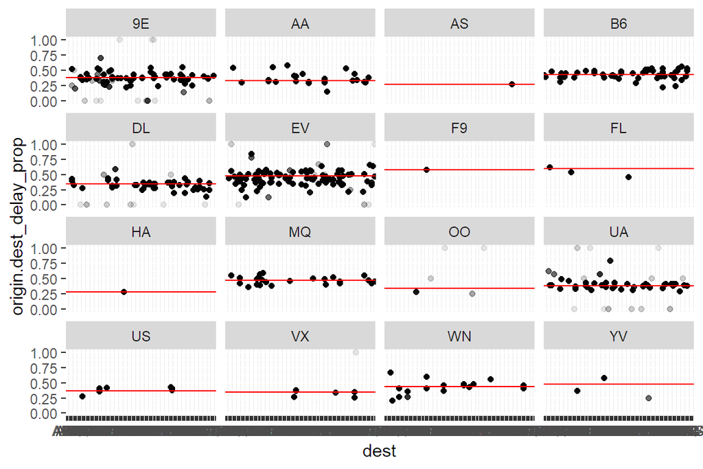

```r
vs = flights %>%
  group_by(carrier) %>%
  mutate(delay_prop=mean(arr_delay>0, na.rm=TRUE)) %>% ungroup() %>%
  group_by(carrier,origin,dest) %>%
  mutate(origin.dest_delay_prop = mean(arr_delay>0, na.rm=TRUE))

vs %>%
  ggplot() +
  geom_point(mapping=aes(x=dest, y=origin.dest_delay_prop) ,alpha=0.1)  +
  geom_hline(aes(yintercept=delay_prop),col="red") + facet_wrap(~carrier)
```

- 위의 그래프를 보면 9E, DL, EV, UA carrier의 경우 origin-destination에 따라 delay가 될 확률이 carrier만 고려하였을 때 delay가 될 확률보다 높거나 낮은 경우가 있으므로 어느 정도 구분은 가능하나 나머지느 대체로 carrie만 고려하였을 때의 확률과 유사한 것으로 보여 구분이 어려워 보인다.
4. Counts the number of flights to a destination and sorts them from highest to lowest.

```r
flights %>% group_by(dest) %>%
  summarise(n=n()) %>% arrange(desc(n))
```

```
## # A tibble: 105 x 2
##    dest      n
##    <chr> <int>
##  1 ORD   17283
##  2 ATL   17215
##  3 LAX   16174
##  4 BOS   15508
##  5 MCO   14082
##  6 CLT   14064
##  7 SFO   13331
##  8 FLL   12055
##  9 MIA   11728
## 10 DCA    9705
## # ... with 95 more rows
```

- ORD에 17283개가 가장 많이 비행기가 도착하였고 LEX와 LGA는 1개로 가장 적게 비행기가 도착하였다.

### p.65 - p.69

1. Which plane (tailnum) has the worst on-time record?  
   1-1) proportion of flights not delayed or canceled, and

```r
flights %>%
  filter(!is.na(tailnum)) %>%
  group_by(tailnum) %>%
  mutate(prop = mean(arr_delay <=0 & (!is.na(arr_delay)|!is.na(dep_delay))), na.rm=TRUE) %>%
  select(tailnum, prop) %>%  arrange(prop)
```

```
## # A tibble: 334,264 x 2
## # Groups:   tailnum [4,043]
##    tailnum  prop
##    <chr>   <dbl>
##  1 N26906      0
##  2 N801AW      0
##  3 N383SW      0
##  4 N835MH      0
##  5 N17627      0
##  6 N624AW      0
##  7 N953FR      0
##  8 N589AS      0
##  9 N965DN      0
## 10 N635SW      0
## # ... with 334,254 more rows
```

- prop이 낮을수록 delay나 cancel이 많은 나쁜 plane이다.

1-2) mean arrival delay.

```r
flights %>% group_by(tailnum) %>%
  mutate(arr_delay_mean = mean(arr_delay>0, na.rm=TRUE)) %>%
  select(tailnum, arr_delay_mean) %>% arrange(desc(arr_delay_mean))
```

```
## # A tibble: 336,776 x 2
## # Groups:   tailnum [4,044]
##    tailnum arr_delay_mean
##    <chr>            <dbl>
##  1 N26906               1
##  2 N801AW               1
##  3 N383SW               1
##  4 N835MH               1
##  5 N17627               1
##  6 N624AW               1
##  7 N953FR               1
##  8 N589AS               1
##  9 N965DN               1
## 10 N635SW               1
## # ... with 336,766 more rows
```

- arr_delay_mean이 더 높을수록 delay가 많은 나쁜 plane이다.
2. What time of day should you fly if you want to avoid delays as much as possible? (Hint: The earlier the flight is scheduled, the lower its expected delay.)

```r
flights = flights %>%
  mutate(sched_dep_min = ((sched_dep_time%/%100)*60 + sched_dep_time%%100)%%1440,)

(not = flights %>%
  group_by(sched_dep_min) %>%
  mutate(not_delay = sum(arr_delay<=0, na.rm=TRUE),
         n = n(),
         not_prop = not_delay/n) %>%
  select(sched_dep_min, not_delay, n, not_prop) %>%
  arrange(desc(not_prop)))
```

```
## # A tibble: 336,776 x 4
## # Groups:   sched_dep_min [1,021]
##    sched_dep_min not_delay     n not_prop
##            <dbl>     <int> <int>    <dbl>
##  1           320         7     7        1
##  2           320         7     7        1
##  3           320         7     7        1
##  4           320         7     7        1
##  5           320         7     7        1
##  6           328         1     1        1
##  7           357         3     3        1
##  8          1321         1     1        1
##  9           301         1     1        1
## 10           355         2     2        1
## # ... with 336,766 more rows
```

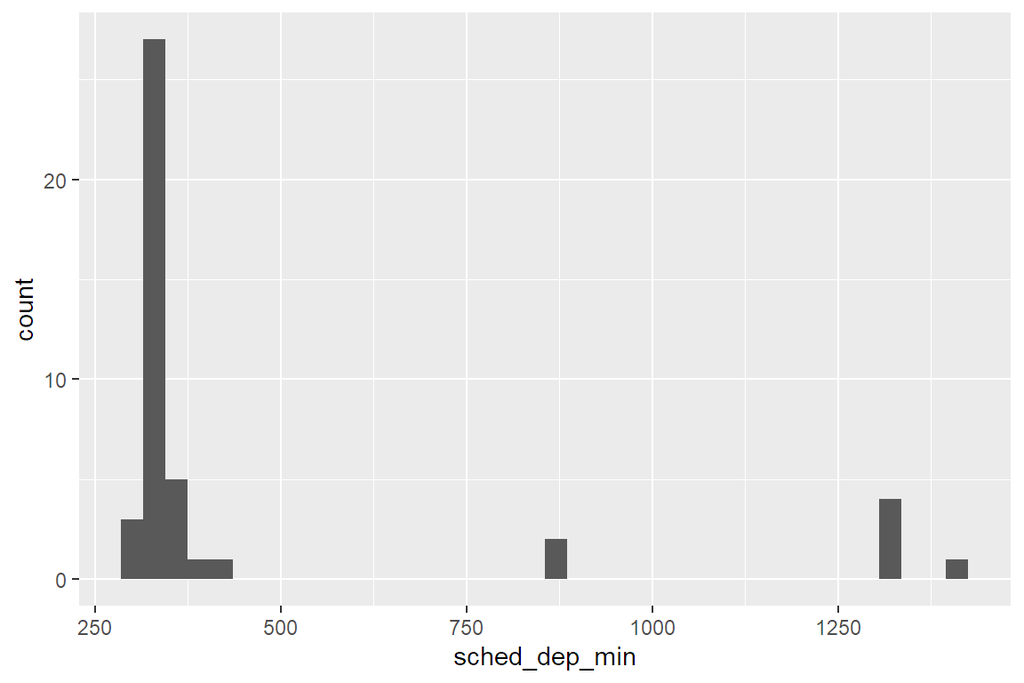

```r
not %>% filter(not_prop==1) %>%
  ggplot(aes(x=sched_dep_min)) +
  geom_histogram(xlim=c(0,1440),binwidth=30)
```

- 약 300-330 minute, 즉 오전 5시-5시30분에 출발 하는 것이 가장 delay를 피할 수 있다.

3-1) For each destination, compute the total minutes of delay.

```r
dest = flights %>%
  filter(arr_delay>0) %>%
  group_by(dest) %>%
  mutate(total = sum(arr_delay)) %>%
  select(dest,flight,arr_delay, total)

dest %>% arrange(total)
```

```
## # A tibble: 133,004 x 4
## # Groups:   dest [103]
##    dest  flight arr_delay total
##    <chr>  <int>     <dbl> <dbl>
##  1 PSP       55         1    36
##  2 PSP       55         1    36
##  3 PSP       55         4    36
##  4 PSP       55         8    36
##  5 PSP       55        17    36
##  6 PSP       55         5    36
##  7 ANC      887         1    62
##  8 ANC      887         2    62
##  9 ANC      887        10    62
## 10 ANC      887        10    62
## # ... with 132,994 more rows
```

```r
dest %>% arrange(desc(total))
```

```
## # A tibble: 133,004 x 4
## # Groups:   dest [103]
##    dest  flight arr_delay  total
##    <chr>  <int>     <dbl>  <dbl>
##  1 ATL     4650        12 300299
##  2 ATL     1547         5 300299
##  3 ATL      346        17 300299
##  4 ATL     4654         6 300299
##  5 ATL      347         2 300299
##  6 ATL     4876        11 300299
##  7 ATL     4658        22 300299
##  8 ATL     1947         1 300299
##  9 ATL     3850        24 300299
## 10 ATL      781         4 300299
## # ... with 132,994 more rows
```

- total = 각 목적지에 대한 총 delay 시간 - 가장 delay가 짧은 곳 = PSP  
  - 가장 delay가 많은 곳 = ATL

3-2) For each flight, compute the proportion of the total delay for its destination.

```r
dest %>%
  group_by(flight) %>%
  mutate(prop = arr_delay/total) %>%
  arrange(prop)
```

```
## # A tibble: 133,004 x 5
## # Groups:   flight [3,432]
##    dest  flight arr_delay  total       prop
##    <chr>  <int>     <dbl>  <dbl>      <dbl>
##  1 ATL     1947         1 300299 0.00000333
##  2 ATL     2043         1 300299 0.00000333
##  3 ATL     1743         1 300299 0.00000333
##  4 ATL      349         1 300299 0.00000333
##  5 ATL     1647         1 300299 0.00000333
##  6 ATL      781         1 300299 0.00000333
##  7 ATL     1499         1 300299 0.00000333
##  8 ATL     4662         1 300299 0.00000333
##  9 ATL     4669         1 300299 0.00000333
## 10 ATL      847         1 300299 0.00000333
## # ... with 132,994 more rows
```

- prop = 항공편의 목적지에 대한 delay 비율
4. Delays are typically temporally correlated: even once the problem that caused the initial delay has been resolved, later flights are delayed to allow earlier flights to leave. Draw a the scatter plot between mean of dep_delay of flights and the dep_delay of the immediately preceding flight. Hint 1: Using lag(), explore how the delay of a flight is related to the delay of the immediately preceding flight. Use lag() to get the info of dep_delay of a previous flight in the same origin. Before using lag(), the data should be ordered by origin, month, day, dep_time. Hint 2: group by the dep_delay of the immediately preceding flight and find the mean of dep_delay of current flights.

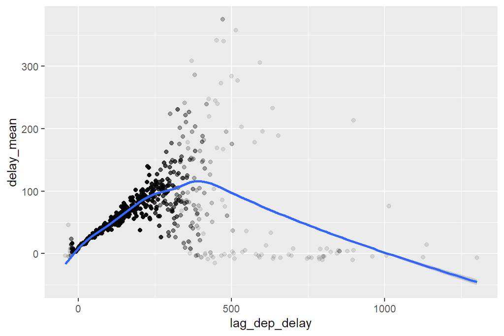

```r
corr = flights %>%
  select(origin, year, month, day, dep_time, dep_delay) %>%
  arrange(origin,year, month, day, dep_time) %>%
  group_by(origin) %>%
  mutate(lag_dep_delay = lag(dep_delay))

corr %>%
  group_by(lag_dep_delay) %>%
  mutate(delay_mean = mean(dep_delay, na.rm=TRUE)) %>%
  ggplot(mapping=aes(x=lag_dep_delay,y=delay_mean)) +
  geom_point(alpha=0.1) + geom_smooth()
```

- 이전 항공편의 출발의 지연과 다음 항공편의 지연의 상관성을 보기 위한 산점도이다.  
  -> 위의 산점도를 보면, 이전 항공편의 출발이 지연될수록 양의 상관관계로 다음 항공편 또한 지연될 가능성이 높음을 알 수 있다.

5) Look at each destination. Can you find flights that are suspiciously fast? (i.e. flights that represent a potential data entry error). Compute the air time of a flight relative to the shortest flight to that destination. Which flights were most delayed in the air? Hint: Standardize air time.

```r
flights %>%
  arrange(air_time) %>%
  select(year,month,day,air_time, origin, dest, carrier, everything())
```

```
## # A tibble: 336,776 x 20
##     year month   day air_time origin dest  carrier dep_time sched_dep_time
##    <int> <int> <int>    <dbl> <chr>  <chr> <chr>      <int>          <int>
##  1  2013     1    16       20 EWR    BDL   EV          1355           1315
##  2  2013     4    13       20 EWR    BDL   EV           537            527
##  3  2013    12     6       21 EWR    BDL   EV           922            851
##  4  2013     2     3       21 EWR    PHL   EV          2153           2129
##  5  2013     2     5       21 EWR    BDL   EV          1303           1315
##  6  2013     2    12       21 EWR    PHL   EV          2123           2130
##  7  2013     3     2       21 LGA    BOS   US          1450           1500
##  8  2013     3     8       21 JFK    PHL   9E          2026           1935
##  9  2013     3    18       21 EWR    BDL   EV          1456           1329
## 10  2013     3    19       21 EWR    BDL   EV          2226           2145
## # ... with 336,766 more rows, and 11 more variables: dep_delay <dbl>,
## #   arr_time <int>, sched_arr_time <int>, arr_delay <dbl>, flight <int>,
## #   tailnum <chr>, distance <dbl>, hour <dbl>, minute <dbl>, time_hour <dttm>,
## #   sched_dep_min <dbl>
```

- 가장 빠른 비행은 20분이다.

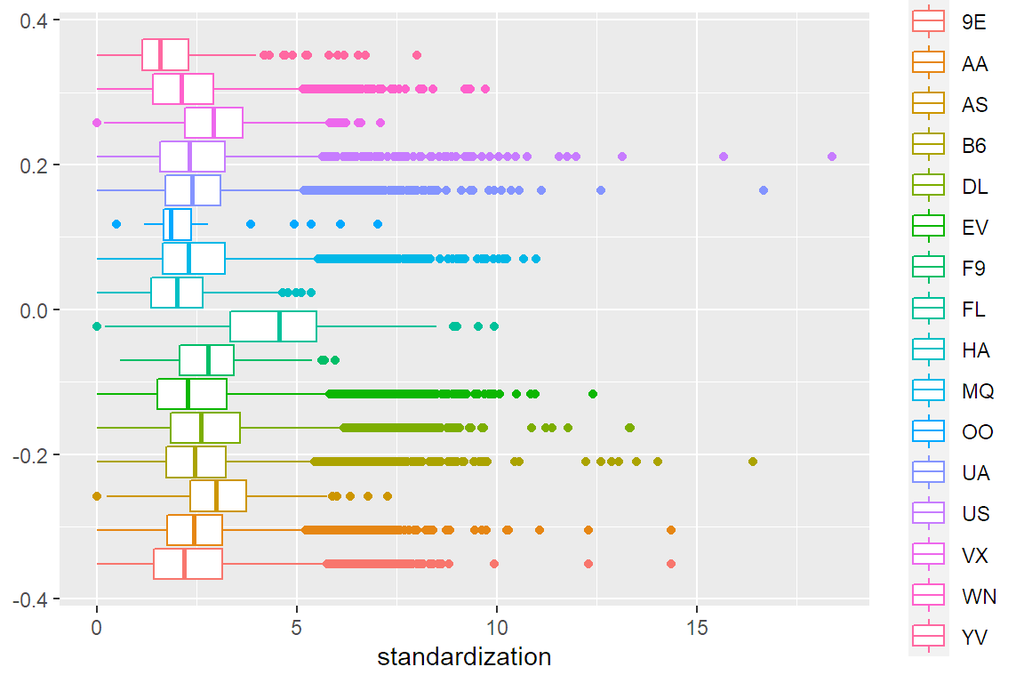

```r
delay = flights %>%
  group_by(origin, dest) %>%
  mutate(min_air_time = min(air_time, na.rm=TRUE),
         delay_in_air = air_time - min_air_time,
         sd_air = sd(air_time, na.rm=TRUE),
         standardization = delay_in_air/sd_air) %>%
  select(air_time, origin, dest, carrier, min_air_time,
         delay_in_air, sd_air, standardization, everything()) %>%
  arrange(origin,dest)

delay %>%
  ggplot(aes(standardization)) +
  geom_boxplot(aes(colour= carrier))
```

```r
car = flights %>%
  group_by(dest) %>%
  filter(length(unique(carrier))>=2)
car %>%
  group_by(dest) %>%
  summarise(carrier_n = length(unique(carrier)))
```

```
## # A tibble: 76 x 2
##    dest  carrier_n
##    <chr>     <int>
##  1 ATL           7
##  2 AUS           6
##  3 AVL           2
##  4 BDL           2
##  5 BGR           2
##  6 BNA           5
##  7 BOS           7
##  8 BQN           2
##  9 BTV           3
## 10 BUF           4
## # ... with 66 more rows
```

- carrier가 2개 이상으로 비행하는 목적지는 위와 같다.

```r
car %>%
  group_by(carrier) %>%
  summarise(dest_n=length(unique(dest))) %>%
  arrange(desc(dest_n))
```

```
## # A tibble: 16 x 2
##    carrier dest_n
##    <chr>    <int>
##  1 EV          51
##  2 9E          48
##  3 UA          42
##  4 DL          39
##  5 B6          35
##  6 AA          19
##  7 MQ          19
##  8 WN          10
##  9 OO           5
## 10 US           5
## 11 VX           4
## 12 YV           3
## 13 FL           2
## 14 AS           1
## 15 F9           1
## 16 HA           1
```

- 각 carrier마다 비행하는 목적지의 수를 구하고 이를 가장 많은 순부터 나열하였다.  
  -> 이에 따르면 EV carrier가 가장 많은 목적지로 가는 carrier로 순위가 가장 높음을 알 수 있다.